# Webscraping

# Manipulação dos dados e análise

Como as datas tem muitos erros e demoraria muito tempo para consertar do que o resto que foi feito com a limpeza de dados não vou trabalhar com a coluna `Data de Lançamento`

Quantos vocaloids cantam em japonês, coreano, chinês, espanhol e inglês, qual é a lingua predominante?

```r
VOCALOIDS_2 %>%
  gather(Idioma, valor, -c(Personagem,Desenvolvedor,Provedor_da_voz,Sexo,Versao_Vocaloid)) %>%
  group_by(Idioma, valor) %>% summarize(count = n()) %>%
  arrange(desc(count)) %>% drop_na()
```

```
## # A tibble: 6 x 3
## # Groups:   Idioma [1]
##   Idioma valor            count
##   <chr>  <chr>            <int>
## 1 Idioma Japonês            120
## 2 Idioma Inglês              64
## 3 Idioma Chinês(mandarim)    14
## 4 Idioma Chinês(taiwan)       3
## 5 Idioma Coreano              3
## 6 Idioma Espanhol             3
```

Depois de analisar esta tabela percebemos que a língua mais cantada pelos vocaloids é o Japonês.

Atualmente eu sei que o vocaloid mais famoso é a Hatsune Miku, vamos ver se é o nome dela aparece mais vezes. Os 6 vocaloids mais famosos são os que apresentam o show oficial no Japão (Magical Mirai) são: Hatsune Miku, Kagamine Len, Kagamine Rin, Kaito, Meiko e Megurine Luka da empresa Crypton. Eu procurei tudo que começava escrito com Hatsune Miku para deixar seu nome único pois há várias versões de vocaloids lançadas e geralmente muda-se o nome no final falando qual versão lançou.

```r
VOCALOIDS_2 %>%
  mutate(Personagem = str_replace(Personagem, "Ha.*$", "Hatsune Miku"),
         #Chuyin e a versao chinesa de hatsune miku
         Personagem = str_replace(Personagem, "Chuyin.*$", "Hatsune Miku")) %>%
  gather(Personagem, valor, -c(Idioma,Desenvolvedor,Provedor_da_voz,Sexo,Versao_Vocaloid)) %>%
  group_by(Personagem, valor) %>% summarise(count = n()) %>% arrange(desc(count)) %>% drop_na() %>%
  top_n(1)
```

```
## # A tibble: 1 x 3
## # Groups:   Personagem [1]
##   Personagem valor        count
##   <chr>      <chr>        <int>
## 1 Personagem Hatsune Miku    13
```

Como podemos ver o nome de Hatsune Miku aparece mais vezes.

Resolvi fazer este gráfico para analisar quais desenvolvedores lançam mais versões de vocaloids, ou seja, mais atualizam seus Personagens(os cantores virtuais).

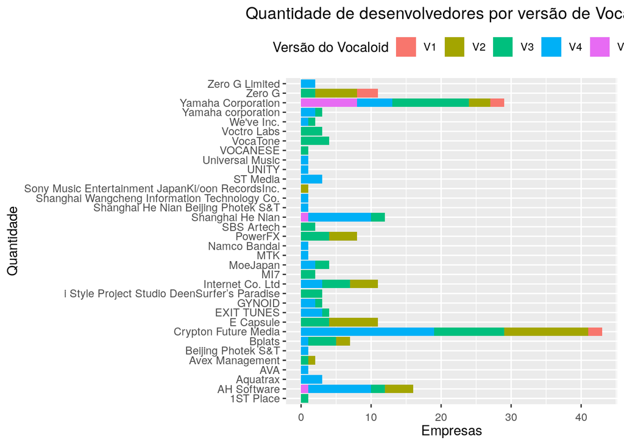

```r
VOCALOIDS_2 %>%
  gather(Tipos, valor, -c(Personagem,Idioma,Provedor_da_voz,Sexo,Versao_Vocaloid))%>%
  group_by(Tipos, valor, Versao_Vocaloid) %>% summarise(count = n()) %>%
  arrange(desc(count)) %>% drop_na() %>%
  ggplot(aes(x = valor, y = count, fill = Versao_Vocaloid)) +
  geom_bar( stat = "identity") + coord_flip() +
  ggtitle("Quantidade de desenvolvedores por versão de Vocaloid") +
  xlab("Quantidade") + ylab("Empresas") +
  theme(axis.text.x = element_text(vjust=0.2), legend.position="top",
        plot.title = element_text(hjust = 0.5)) +
  scale_fill_discrete(name="Versão do Vocaloid",
                      breaks=c("V1", "V2", "V3", "V4", "V5"))
```

# Fechando a conexão

```r
dbDisconnect(vocaloids)
```